# **Cameron Peak Fire**

## We have now identified:

- **"Danger Zone"** i.e. areas that burned at high severity occurring on steep slopes
- **watersheds** that contain some portion of the Danger Zone
- **streams** that run through the Danger Zone
- **lakes** in watersheds containing the Danger Zone

### Our final tasks:

- print .csv file showing total Danger Zone area within each water shed
- print .csv file showing which lakes are in watersheds containing the Danger Zone
- make a nice plot that shows all of this data together

```python
# Let's clean up the table so we can print a little report

shed_pre_csv = shed_dissolve.drop(['geometry', 'index_left', "States", 'Shape_Area', "DN"], axis = 1)

shed_pre_csv.head()
```

| Name | at_risk_area_hectares |
| --- | --- |
| Beaver Creek | 14.864772 |
| Bennett Creek | 245.638315 |
| Black Hollow-Cache la Poudre River | 634.857554 |
| Hague Creek | 6.819942 |
| Headwaters Cache la Poudre River | 26.288275 |

```python
shed_pre_csv.to_csv(os.path.join(reports,'AtRiskArea_byWatershed.csv'))
print("This just in: We created a .csv file containing a list of affected watersheds, along with the total at-risk area in each watershed that burned at high severity and is located on steep slopes.")
print("\nThis file is located in the reports folder we created earlier.")
```

```
This just in: We created a .csv file containing a list of affected watersheds, along with the total at-risk area in each watershed that burned at high severity and is located on steep slopes.

This file is located in the reports folder we created earlier.
```

```python
# Let's save a list of the water bodies larger than 10 hectares as a .csv file

risklakes_simplify = biglakes.drop(['co_fips', 'shape_area', 'shape_len'], axis=1)

lakesindanger = gpd.sjoin(shed_simplify, risklakes_simplify, how= "right", op = "intersects")
lakesindanger.head()
```

|  | index_left | States | Name | Shape_Area | name | geometry | hectares |
| --- | --- | --- | --- | --- | --- | --- | --- |
| 641 | 2601 | CO | Rawah Creek-Laramie River | 0.015948 | Upper Camp Lake | POLYGON ((421965.500 4504257.000, 422013.500 4... | 16.417650 |
| 656 | 2601 | CO | Rawah Creek-Laramie River | 0.015948 | None | POLYGON ((419018.907 4502978.000, 419051.437 4... | 10.494648 |
| 1690 | 2721 | CO | Beaver Creek | 0.006089 | Comanche Reservoir | POLYGON ((444224.719 4493008.000, 444323.812 4... | 44.863042 |
| 1722 | 2727 | CO | Joe Wright Creek | 0.010538 | Barnes Meadow Reservoir | POLYGON ((429265.031 4494704.500, 429303.187 4... | 26.868277 |
| 2678 | 2727 | CO | Joe Wright Creek | 0.010538 | Chambers Lake | POLYGON ((427460.531 4496396.500, 427485.843 4... | 96.288561 |

```python
lakes_precsv = lakesindanger.drop(['index_left', 'States', 'Shape_Area', 'geometry'], axis = 1)
```

```python
lakes_precsv.head()
```

|  | Name | name | hectares |
| --- | --- | --- | --- |
| 641 | Rawah Creek-Laramie River | Upper Camp Lake | 16.417650 |
| 656 | Rawah Creek-Laramie River | None | 10.494648 |
| 1690 | Beaver Creek | Comanche Reservoir | 44.863042 |
| 1722 | Joe Wright Creek | Barnes Meadow Reservoir | 26.868277 |
| 2678 | Joe Wright Creek | Chambers Lake | 96.288561 |

```python
lakes_precsv.columns = ['Watershed', "Lake_Name", "Lake_Area_hectares"]
lakes_precsv.head()
```

|  | Watershed | Lake_Name | Lake_Area_hectares |
| --- | --- | --- | --- |
| 641 | Rawah Creek-Laramie River | Upper Camp Lake | 16.417650 |
| 656 | Rawah Creek-Laramie River | None | 10.494648 |
| 1690 | Beaver Creek | Comanche Reservoir | 44.863042 |
| 1722 | Joe Wright Creek | Barnes Meadow Reservoir | 26.868277 |
| 2678 | Joe Wright Creek | Chambers Lake | 96.288561 |

```python
lakesindanger.to_file(os.path.join(newdata, "LakesinAffectedWatersheds.shp"))
lakes_precsv.to_csv(os.path.join(reports, r'AtRisk_Lakes.csv'))
print("This just in: We created a .csv file containing a list of the lakes > 10 hectares) in affected watersheds.")
print("This file is also located in the 'reports' folder we created earlier.")
print("\nWe also saved a shapefile of At Risk Lakes (in affected watersheds) in the 'newlayers' folder.")
```

```
This just in: We created a .csv file containing a list of the lakes > 10 hectares) in affected watersheds.
This file is also located in the 'reports' folder we created earlier.

We also saved a shapefile of At Risk Lakes (in affected watersheds) in the 'newlayers' folder.
```

```python
# Let's try to label the watersheds in our new figure


affectedsheds["center"] = affectedsheds["geometry"].centroid
shed_points = affectedsheds.copy()
shed_points.set_geometry("center", inplace = True)
```

```
We saved a copy of this map in your reports folder, for your viewing pleasure.
```

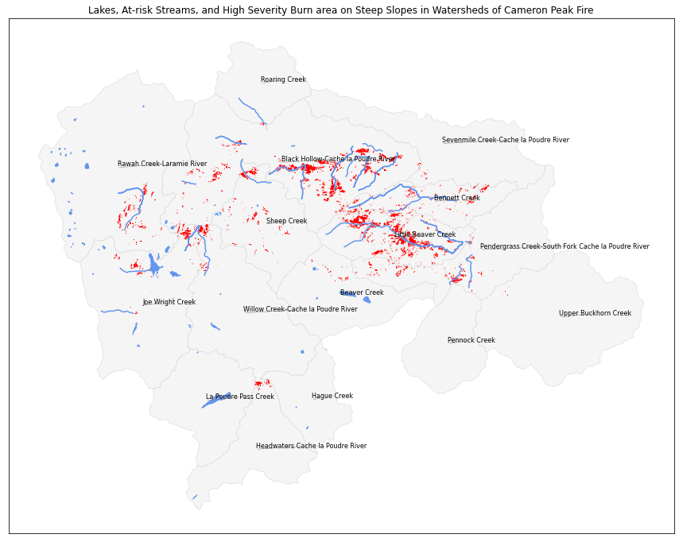

```python
# This code labels each watersheds
# Adapted from...
# Source:  https://github.com/shotleft/how-to-python/blob/master/How%20it%20works%20-%20labelling%20districts%20in%20GeoPandas.ipynb



ax = affectedsheds.plot(figsize = (15, 12), color = "whitesmoke", edgecolor = "lightgrey", linewidth = 0.5)


# sets aspect to equal. This is done automatically
# when using *geopandas* plot on it's own, but not when
# working with pyplot directly.
# Source:  https://geopandas.org/mapping.html


ax.set_aspect('equal')
ax.set_title('Lakes, At-risk Streams, and High Severity Burn area on Steep Slopes in Watersheds of Cameron Peak Fire')


texts = []

for x, y, label in zip(shed_points.geometry.x, shed_points.geometry.y, shed_points["Name"]):
    texts.append(plt.text(x, y, label, fontsize = 8))

aT.adjust_text(texts, force_points=0.3, force_text=0.8, expand_points=(1,1), expand_text=(1,1),
               arrowprops=dict(arrowstyle="-", color='grey', lw=0.5))

# hide axis ticks/text
ax.axes.get_xaxis().set_visible(False)
ax.axes.get_yaxis().set_visible(False)


# Now adding all lakes in affected sheds, but only the streams that run through the high-risk areas

dangerstreams.plot(ax=ax, marker = 'o',  color = 'cornflowerblue', markersize =10)


atrisk_lakes.plot(ax=ax, marker='o',  color='cornflowerblue', markersize=5)


dangerzone.plot(ax=ax, marker='o', color='red',  markersize=5)

# let's save this plot as well
plt.savefig(os.path.join(reports, 'DangerZone.pdf'))
print("We saved a copy of this map in your reports folder, for your viewing pleasure.")
```

## Take a look in the original folder where the .ipynb notebook file is located You should see:

- zip files for the DEM, BAER burn severity, and polygonized slope data downloaded from the internet
- "zipcontents" folder containing all data that was unzipped from those files
- "newlayers" folder containing .tif and .shp files created during the script that could be useful in the future
- "reports" folder containing
  1. a lovely .pdf showing **watersheds** in the **"Danger Zone"**, **streams** that run through high risk areas, and **lakes** within the affected areas
  2. a .csv report of total high severity / steep slope area within each watershed
  3. a .csv report of lakes larger than 10 hectares within affected watersheds

[figure not shown]